# Chapter 3

Nikunj Goel

9/26/2020

### Loading Libraries

```r
library(astsa)
```

## 3.1

### Part a)

```r
trend = time(jj) - 1970
q = factor(cycle(jj))
req = lm(log(jj) ~ 0 + trend + q, na.action = NULL)
model.matrix(req)
```

```
##     trend q1 q2 q3 q4
## 1  -10.00  1  0  0  0
## 2   -9.75  0  1  0  0
## 3   -9.50  0  0  1  0
## 4   -9.25  0  0  0  1
## 5   -9.00  1  0  0  0
## 6   -8.75  0  1  0  0
## 7   -8.50  0  0  1  0
## 8   -8.25  0  0  0  1
## 9   -8.00  1  0  0  0
## 10  -7.75  0  1  0  0
## 11  -7.50  0  0  1  0
## 12  -7.25  0  0  0  1
## 13  -7.00  1  0  0  0
## 14  -6.75  0  1  0  0
```

[output cut: 75 more lines]

```r
summary(req)
```

```
##
## Call:
## lm(formula = log(jj) ~ 0 + trend + q, na.action = NULL)
##
## Residuals:
##      Min       1Q   Median       3Q      Max
## -0.29318 -0.09062 -0.01180  0.08460  0.27644
##
## Coefficients:
##       Estimate Std. Error t value Pr(>|t|)
## trend 0.167172   0.002259   74.00   <2e-16 ***
## q1    1.052793   0.027359   38.48   <2e-16 ***
## q2    1.080916   0.027365   39.50   <2e-16 ***
## q3    1.151024   0.027383   42.03   <2e-16 ***
## q4    0.882266   0.027412   32.19   <2e-16 ***
## ---
## Signif. codes:  0 '***' 0.001 '**' 0.01 '*' 0.05 '.' 0.1 ' ' 1
##
## Residual standard error: 0.1254 on 79 degrees of freedom
## Multiple R-squared:  0.9935, Adjusted R-squared:  0.9931
## F-statistic:  2407 on 5 and 79 DF,  p-value: < 2.2e-16
```

### Part b)

The estimated average annual increase in the logged earnings per share is
$$trend$$
which can be extracted from the summary table

```r
0.167
```

```
## [1] 0.167
```

### Part c)

Average logged earning rate $q4$ - $q3$ decreases.

```r
0.882266 - 1.151024
```

```
## [1] -0.268758
```

The percentage of the decrease is

```r
(0.269/1.151024) * 100
```

```
## [1] 23.37049
```

### Part d)

```r
trend = time(jj) - 1970
q = factor(cycle(jj))
req = lm(log(jj) ~ trend + q, na.action = NULL)
summary(req)
```

```
##
## Call:
## lm(formula = log(jj) ~ trend + q, na.action = NULL)
##
## Residuals:
##      Min       1Q   Median       3Q      Max
## -0.29318 -0.09062 -0.01180  0.08460  0.27644
##
## Coefficients:
##              Estimate Std. Error t value Pr(>|t|)
## (Intercept)  1.052793   0.027359  38.480  < 2e-16 ***
## trend        0.167172   0.002259  73.999  < 2e-16 ***
## q2           0.028123   0.038696   0.727   0.4695
## q3           0.098231   0.038708   2.538   0.0131 *
## q4          -0.170527   0.038729  -4.403 3.31e-05 ***
## ---
## Signif. codes:  0 '***' 0.001 '**' 0.01 '*' 0.05 '.' 0.1 ' ' 1
##
## Residual standard error: 0.1254 on 79 degrees of freedom
## Multiple R-squared:  0.9859, Adjusted R-squared:  0.9852
## F-statistic:  1379 on 4 and 79 DF,  p-value: < 2.2e-16
```

Having an intercept removes the first quarter away. Also the intercept appears in all the quarters. It is of no use because we want to analyze all the quarters separately.

### Part e)

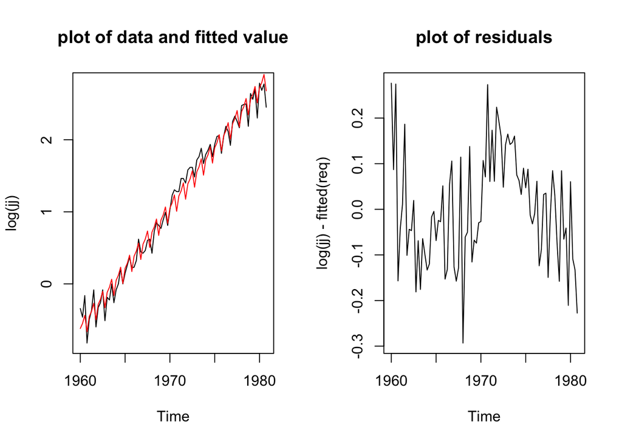

```r
par(mfrow=c(1,2))
plot(log(jj), main="plot of data and fitted value")
lines(fitted(req), col="red")
plot(log(jj) - fitted(req), main="plot of residuals")
```

## 3.2

### Part a)

```r
temp = tempr - mean(tempr)
temp2 = temp^2
trend = time(cmort)
partL4 = lag(part, -4)

ded = ts.intersect(cmort, trend, temp, temp2, part, partL4)
fit = lm(cmort ~ trend + temp + temp2 + part + partL4, data = ded, na.action = NULL)
summary(fit)
```

```
##
## Call:
## lm(formula = cmort ~ trend + temp + temp2 + part + partL4, data = ded,
##     na.action = NULL)
##
## Residuals:
##     Min      1Q  Median      3Q     Max
## -18.228  -4.314  -0.614   3.713  27.800
##
## Coefficients:
##               Estimate Std. Error t value Pr(>|t|)
## (Intercept)  2.808e+03  1.989e+02  14.123  < 2e-16 ***
## trend       -1.385e+00  1.006e-01 -13.765  < 2e-16 ***
## temp        -4.058e-01  3.528e-02 -11.503  < 2e-16 ***
## temp2        2.155e-02  2.803e-03   7.688 8.02e-14 ***
## part         2.029e-01  2.266e-02   8.954  < 2e-16 ***
## partL4       1.030e-01  2.485e-02   4.147 3.96e-05 ***
## ---
## Signif. codes:  0 '***' 0.001 '**' 0.01 '*' 0.05 '.' 0.1 ' ' 1
##
## Residual standard error: 6.287 on 498 degrees of freedom
## Multiple R-squared:  0.608,  Adjusted R-squared:  0.6041
## F-statistic: 154.5 on 5 and 498 DF,  p-value: < 2.2e-16
```

partL4 has a good significant and model has a good fit.

### Part b)

```r
AIC(fit)/nrow(ded) - log(2*pi)
```

```
## [1] 4.692916
```

```r
BIC(fit)/nrow(ded) - log(2*pi)
```

```
## [1] 4.751563
```

## 3.4

### Part a)

The equation is

$$x_{t} = \beta_{0} + \beta_{1}t + w_{t}$$
Mean of $x_{t}$

$$E[x_{t}] = E[\beta_{0} + \beta_{1}t + w_{t}] = \beta_{0} + \beta_{1}t$$

It is dependent on time t, hence the series $x_{t}$ is not stationary.

### Part b)

The first order difference can be simplified into

$$\Delta x_{t} = x_{t} - x_{t-1}
\\
= \beta_{0} + \beta_{1}t + w_{t} - [\beta_{0} + \beta_{1}(t-1) + w_{t-1}]
\\
= w_{t} - w_{t-1} + \beta_{1}$$
Mean of the function would be

$$E[\Delta x_{t}] = E[w_{t} - w_{t-1} + \beta_{1}]
\\
=\beta_{1} + E[w_{t}] - E[w_{t-1}]
\\
=\beta_{1}$$

Independent of time

and now Auto Covariance Function is:

$$\gamma \Delta x_{t}(t+h,h) = Cov(x_{t+h},x_{t})
\\
= Cov(w_{t+h} - w_{t+h-1} + \beta_{1},w_{t} - w_{t-1} + \beta_{1})
\\
= Cov(w_{t+h} - w_{t+h-1},w_{t} - w_{t-1})
\\
\begin{cases}
2 \sigma^2_{w}, & \text{h=0}
\\
-\sigma^2_{w}, & \text{|h| = 1}
\\
0, & \text{|h|>1}
\end{cases}$$
which is also free from t, hence $\Delta x_{t}$ is stationary.

### Part c)

$$\gamma \Delta x_{t}(t+h,h) = Cov(x_{t+h},x_{t})
\\
=Cov(\beta_{1} + y_{t+h} - y_{t+h-1},\beta_{1} + y_{t} - y_{t-1})
\\
=Cov(y_{t+h} - y_{t+h-1},y_{t} - y_{t-1})
\\
=Cov(y_{t+h},y_{t}) - Cov(y_{t+h},y_{t-1}) -Cov(y_{t+h-1},y_{t}) + Cov(y_{t+h-1},y_{t-1})
\\
=-\gamma_{y}(h+1) + 2\gamma_{y}(h) - \gamma_{y}(h-1)$$
which is independent of time since $y_{t}$ is stationary and $\gamma_{t}$(·)is independent of time t. So it is Stationary.

## 3.6

### Part a)

```r
n = length(varve)
varve1 = varve[1:n/2]
varve2 = varve[(n/2+1):n]
data.frame(firstHalf = var(varve1),SecondHalf=var(varve2))
```

| firstHalf | SecondHalf |
| --- | --- |
| 132.501 | 594.4904 |

as we can see the sample variance in the second half of the data is significanlty larger than the first half,therefore the variance is not homogenous, hence we need to statibilize the variance by data transformation such as log(·)-transformation. Having a log transformation obviously made data closer to the normality.

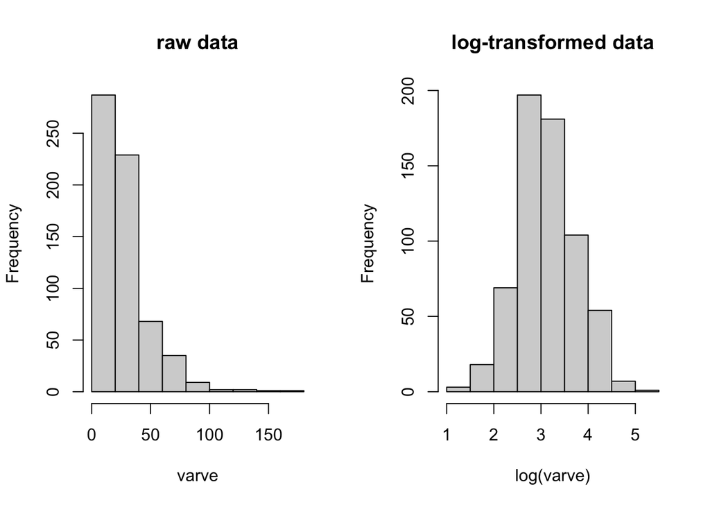

```r
par(mfrow= c(1,2))
hist(varve, main="raw data")
hist(log(varve), main="log-transformed data")
```

### Part b)

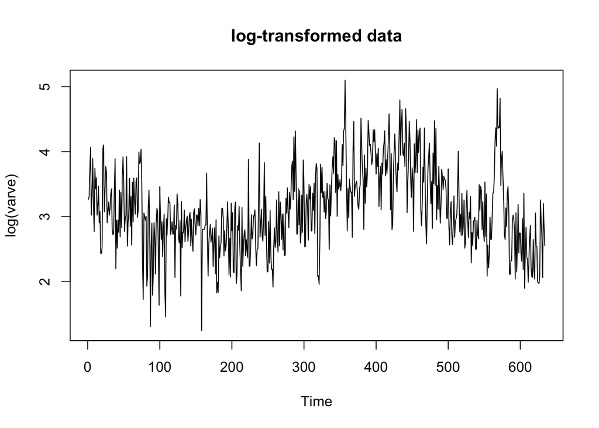

```r
plot(log(varve), main="log-transformed data")
```

It doesn’t that there is an comparable trend over time as compared to gtemp.

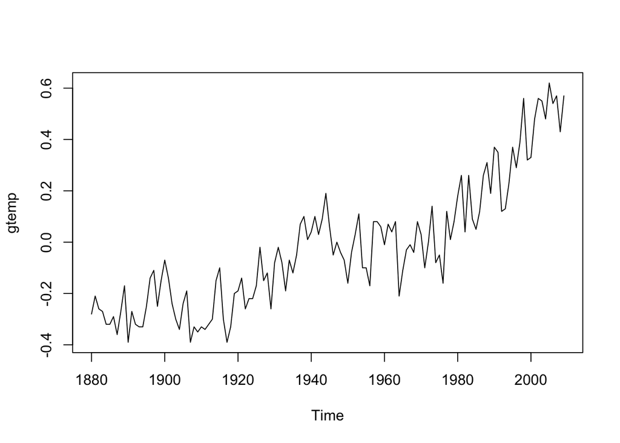

```r
ts.plot(gtemp)
```

### part c)

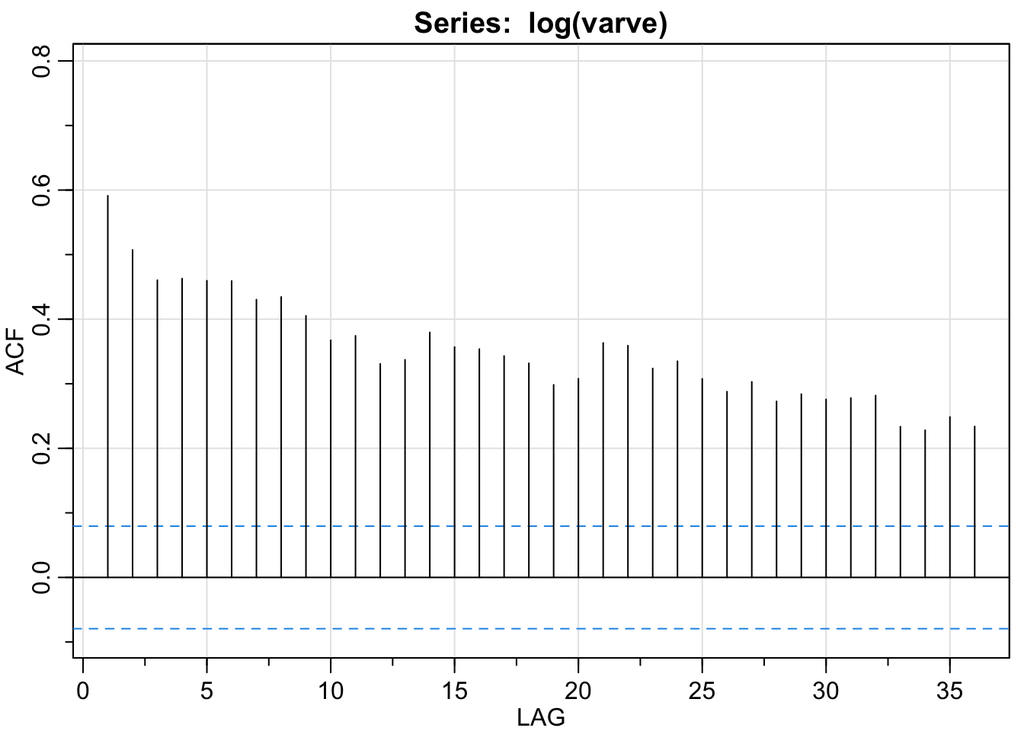

```
##  [1] 0.59 0.51 0.46 0.46 0.46 0.46 0.43 0.43 0.41 0.37 0.37 0.33 0.34 0.38 0.36
## [16] 0.35 0.34 0.33 0.30 0.31 0.36 0.36 0.32 0.33 0.31 0.29 0.30 0.27 0.28 0.28
## [31] 0.28 0.28 0.23 0.23 0.25 0.23
```

```r
acf1(log(varve))
```

that the dependency in the data is very strong in close lags and dies down very slowly.

### Part d)

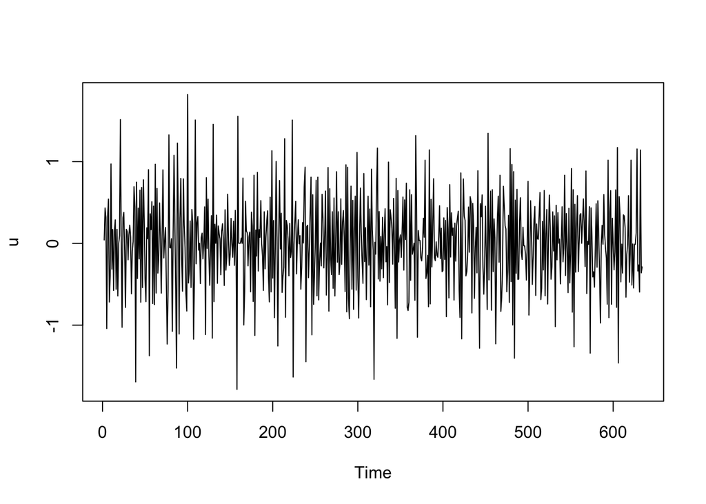

```r
u = diff(log(varve), 1)
plot(u)
```

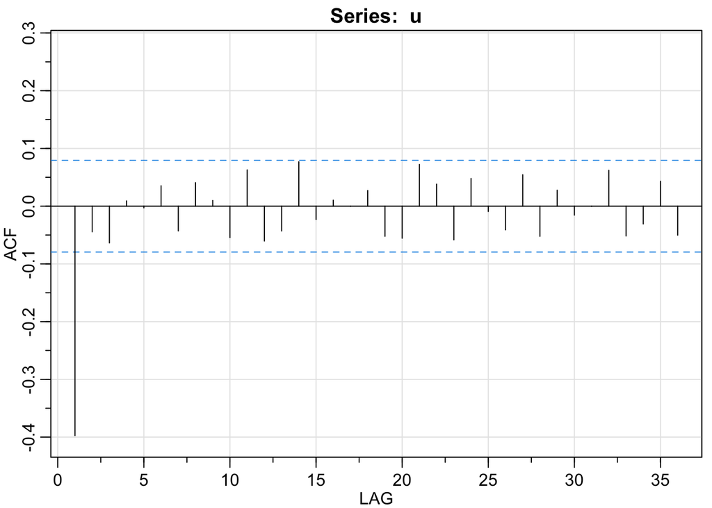

```
##  [1] -0.40 -0.04 -0.06  0.01  0.00  0.04 -0.04  0.04  0.01 -0.05  0.06 -0.06
## [13] -0.04  0.08 -0.02  0.01  0.00  0.03 -0.05 -0.06  0.07  0.04 -0.06  0.05
## [25] -0.01 -0.04  0.05 -0.05  0.03 -0.02  0.00  0.06 -0.05 -0.03  0.04 -0.05
```

```r
acf1(u)
```

Differencing produces fairly reasonable stationary process. $u_{t}$can be interpreted as the yearly increase in the thicknesses varves.

In Statistical sense it can also be smoothing.

$$u_{t} = \Delta y_{t}
\\
=y_{t} - y_{t-1}
\\
=log(x_{t}) - log(x_{t-1})
\\
=log(\frac{x_{t}}{x_{t-1}})
\\
=log(1 + \frac{x_{t} - x_{t-1}}{x_{t-1}})
\\
\approx \frac{x_{t} - x_{t-1}}{x_{t-1}}$$
which can be intepreted as the marginal change in the thickness varves.

## 3.7

**MA Smoothing**

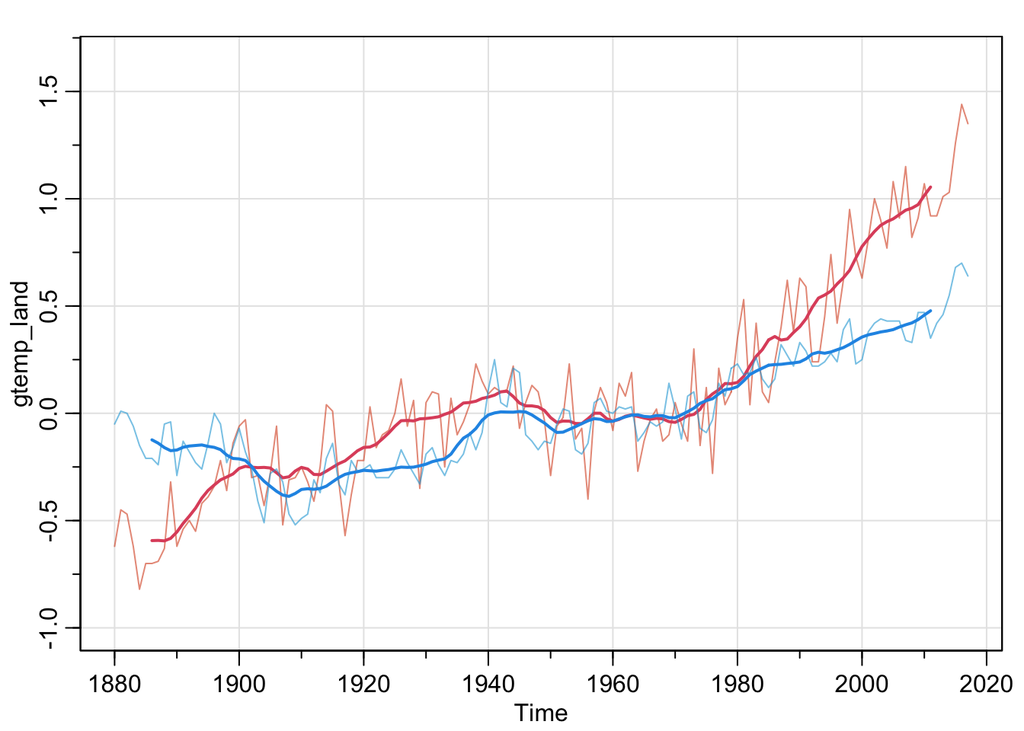

```r
#MA Smoothing
culer = c(rgb(.85,.30,.12,.6), rgb(.12,.65,.85,.6))
w = c(.5, rep(1,11), .5)/12
gtemp_land_f = filter(gtemp_land, sides=2, filter=w)
tsplot(gtemp_land, col=culer[1], ylim=c(-1, 1.65))
lines(gtemp_land_f, lwd=2, col=2)
gtemp_ocean_f = filter(gtemp_ocean, sides = 2, filter = w)
lines(gtemp_ocean, col=culer[2])
lines(gtemp_ocean_f, lwd=2, col=4)
```

**Kernel Smoothing**

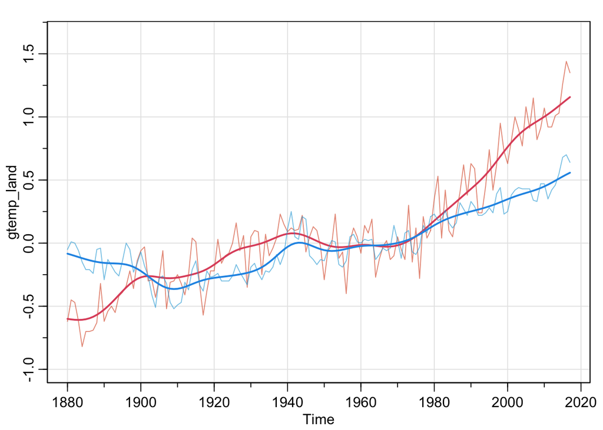

```r
culer = c(rgb(.85,.30,.12,.6), rgb(.12,.65,.85,.6))
w = c(.5, rep(1,11), .5)/12
gtemp_land_f = ksmooth(time(gtemp_land),gtemp_land,"normal", bandwidth = 12)
tsplot(gtemp_land, col=culer[1], ylim=c(-1, 1.65))
lines(gtemp_land_f, lwd=2, col=2)
gtemp_ocean_f = ksmooth(time(gtemp_ocean),gtemp_ocean,"normal", bandwidth = 12)
lines(gtemp_ocean, col=culer[2])
lines(gtemp_ocean_f, lwd=2, col=4)
```

**Lowess Smoothing**

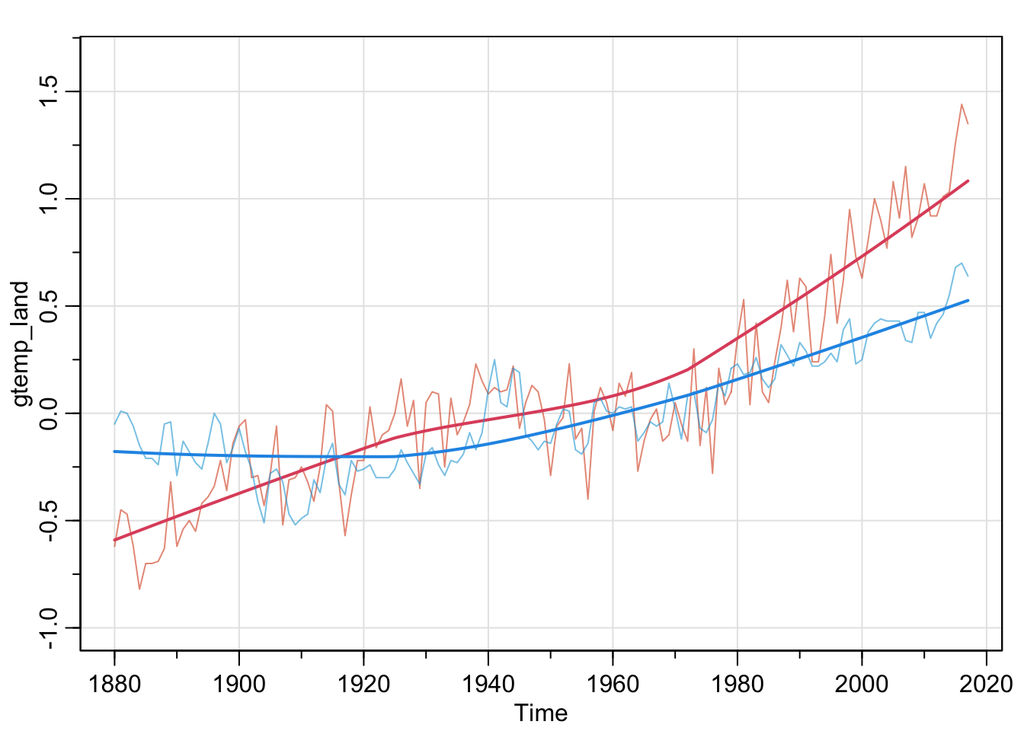

```r
culer = c(rgb(.85,.30,.12,.6), rgb(.12,.65,.85,.6))
w = c(.5, rep(1,11), .5)/12
gtemp_land_f = lowess(gtemp_land)
tsplot(gtemp_land, col=culer[1], ylim=c(-1, 1.65))
lines(gtemp_land_f, lwd=2, col=2)
gtemp_ocean_f = lowess(gtemp_ocean)
lines(gtemp_ocean, col=culer[2])
lines(gtemp_ocean_f, lwd=2, col=4)
```

## 3.9

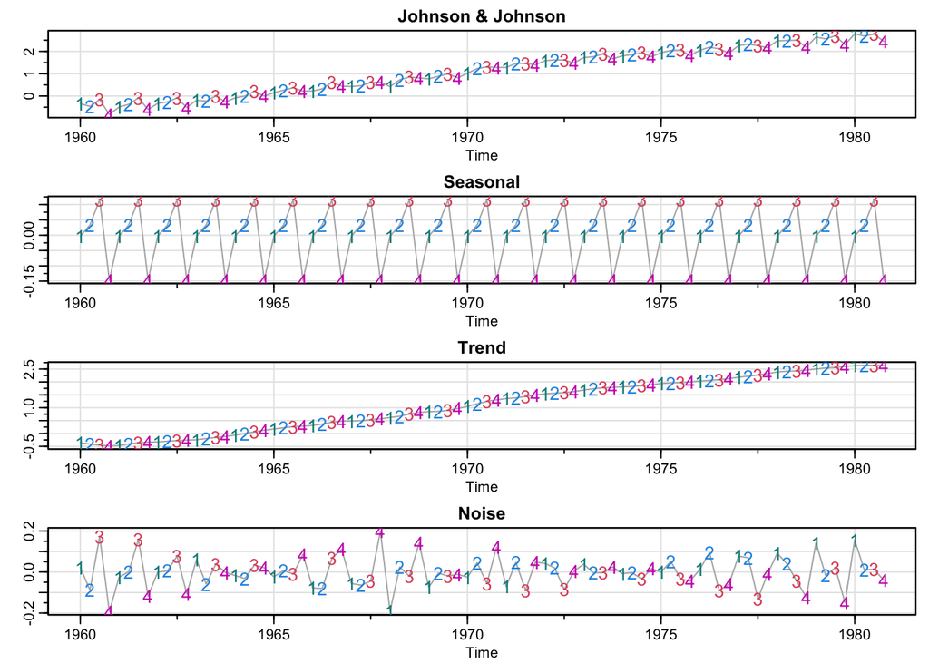

```r
culer = c("cyan4", 4, 2, 6)
par(mfrow = c(4, 1), cex.main = 1)
x = window(log(jj), start = 1960)
out = stl(x, s.window = "periodic")$time.series

tsplot(x, main = "Johnson & Johnson", ylab = "", col = gray(0.7))
text(x, labels = 1:4, col = culer, cex = 1.25)
tsplot(out[,1], main = "Seasonal", ylab = "", col = gray(0.7))
text(out[,1], labels = 1:4, col = culer, cex = 1.25)
tsplot(out[,2], main = "Trend", ylab = "", col = gray(0.7))
text(out[,2], labels = 1:4, col = culer, cex = 1.25)
tsplot(out[,3], main = "Noise", ylab = "", col = gray(0.7))
text(out[,3], labels = 1:4, col = culer, cex = 1.25)
```

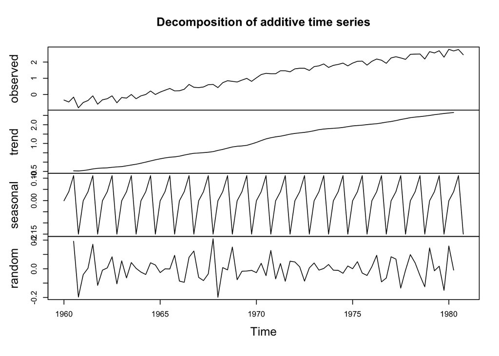

```r
culer = c("cyan4", 4, 2, 6)
par(mfrow = c(4, 1), cex.main = 1)
x = window(log(jj), start = 1960)
plot(decompose(x))
```

The Seasonal plot shows an increase from Q1 to Q2, increase from Q2 to Q3, sharp decrease from Q3 to 4, and an increase back from Q4 to the next Q1. The Trend plot shows a steady increase over the 20 years of the data from quarter to quarter, relatively smooth. The Noise plot shows higher deviations from Q3 and Q4 from the data than Q1 and Q2.